# Towards Machine Learning in Pharo with TensorFlow

In this tutorial we assume Tensorflow lib and binding are installed in your Pharo Image. Follow the installation procedure from libtensorflow-pharo-bindings to install them.

## Let's start with tensorflow

First of all we can get the version of our API

```python
self display openInJupyter:TensorFlowCAPI uniqueInstance version.
```

```
1.8.0
```

Create our first scalar tensor...

```python
myScalar := Float pi asTensor.
self display openInJupyter: myScalar asNumbers.
```

```
3.1415927410125732
```

```python
self display openInJupyter: myScalar.
```

```
a TF_Tensor((void*)@ 16r7FD79721B750) 3.1415927410125732
```

```python
myVector := TF_Tensor fromFloats: #(1 2 3 4 5).
self display openInJupyter: myVector
```

```
a TF_Tensor((void*)@ 16r7FD797461AE0) #(1.0 2.0 3.0 4.0 5.0)
```

```python
myMatrix := TF_Tensor fromFloats: #((1 2 3 4 5)(6 7 8 9 10)).
self display openInJupyter: myMatrix
```

```
a TF_Tensor((void*)@ 16r7FD7977B2B40) #(#(1.0 2.0 3.0 4.0 5.0) #(6.0 7.0 8.0 9.0 10.0))
```

### Ranks and Shapes.

We can ask a tensor for its rank or its shape. Rank is the number of dimensions of a Tensor, shape is the lenght of those dimensions. For example, the rank of a myMatrix will be 2, shape of myMatrix will be 2x5

```python
self display openInJupyter:myMatrix rank
```

```
2
```

```python
self display openInJupyter:myMatrix shape
```

| 2 |
| --- |
| 5 |

## Graphs

A graph contains a set of Operations objects, which represent units of computation; and Tensor objects, which represent the units of data that flow bettween operations.  
Graph can be serialized (as protobuff) and can be exchanged between platforms.

```python
graph := TF_Graph create.
```

Operation is a node in a TF_Graph that takes 0, 1 or n tensors as inputs and produces 0, 1 or n-tensors as output.  
Example of TF operations are:

- Arithmetic operations: Add, Multiply, Mod, etc...
- Mathematic functions: Sin, Exp, Pow, etc...
- Matrix Math functions: Inverse, Norm, etc...
- Reduction dimensions and Segmentation

## Runtime execution

After the dataflow has been defined, the graph is executed within a session and inside a device (CPU, GPU, ...) Graph can also be splitted on many devices for a distributed execution.  
A Dataflow graph is designed to be portable, It is a language-independant representation of the code, so that, it can be re-used in other languages.

### Example 1. 3+4 in TensorFlow

Let's use the graph we have created. We are going to create two constants, c1 and c2 and assign their values, both of them 1-tensor type values, 3.0 and 4.0.

```python
c1 := graph const:'c1' value: 3.0 asTensor.
c2 := graph const:'c2' value: 4.0 asTensor.
```

Next, we create an operation node summing c1 and c2 tensors and a session for our dataflow graph.  
We want to show the output of the operation sum, so that we use the #runOutput: method and we have to provide the output of the sum operation, that is the output 0.

```python
sum := c1 + c2.
session := TF_Session on:graph.
result := session runOutput: (sum output:0).
self display openInJupyter: result asNumbers
```

```
7.0
```

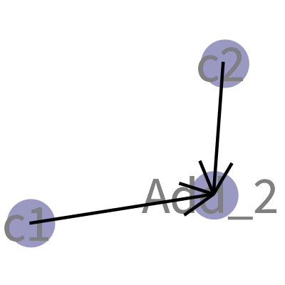

```python
self display
        extent:400@400;
        openInJupyter: graph asRoassalView
```

### Example 2. Multiply two Matrix

In order to multiply two matrix, we are going to create to 2-tensors from two 2-dimensional arrays and declare as imput constants. Following the same procedure as we followed in sum operation, we will build the operation node and the session, after that, we will run the output.

```python
graph := TF_Graph create.
t1 := TF_Tensor fromFloats:#((1 2)(3 4)).
t2 := TF_Tensor fromFloats:#((5 6)(7 8)).
c1 := graph const:'c1' value: t1.
c2 := graph const:'c2' value: t2.
mult := c1 * c2.
session := TF_Session on:graph.
result := session runOutput: (mult output:0).
self display
          extent:400@400;
          openInJupyter: result asNumbers
```

| 19.0 | 22.0 |
| --- | --- |
| 43.0 | 50.0 |

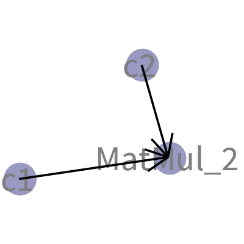

```python
self display
          extent:400@400;
          openInJupyter: graph asRoassalView
```

### Example 3. Neural Network examples

let's make our first example. First of all let's create a tensor of 100x100x100 filled with 0.

```python
graph := TF_Graph create.
zeros := graph zerosShaped: #(100 100 100).
session := TF_Session on: graph.
result := session runOutput: (zeros output: 0).
```

## Regression using NN

It computes a regression on arbitrary functions. Implementation of http://cs.stanford.edu/people/karpathy/convnetjs/demo/regression.html

RegressionNNExample exampleTrainedAndPlot.

```python
| aux |
graph := TF_Graph create.

inputSize := 1.
hidden1Size := 20.
hidden2Size := 20.
hidden3Size := 20.
outputSize := 1.


graph
        fromBlock: [
            aux := graph truncatedNormalRandomShaped: { inputSize. hidden1Size} stddev: 1.0 / inputSize sqrt.
            weights1 := graph variable: 'weights1' initialValueFrom: aux.
            aux := graph zerosShaped: { hidden1Size}.
            biases1 := graph variable: 'biases1' initialValueFrom: aux.

            aux := graph truncatedNormalRandomShaped: { hidden1Size. hidden2Size} stddev: 1.0 /  hidden1Size sqrt.
            weights2 := graph variable: 'weights2' initialValueFrom: aux.
            aux := graph zerosShaped: {hidden2Size}.
            biases2 := graph variable: 'biases2' initialValueFrom: aux.

            aux := graph truncatedNormalRandomShaped: { hidden2Size. hidden3Size } stddev: 1.0 /  hidden2Size sqrt.
            weights3 := graph variable: 'weights3' initialValueFrom: aux.
            aux := graph zerosShaped: { hidden3Size }.
            biases3 := graph variable: 'biases3' initialValueFrom: aux.

            aux := graph truncatedNormalRandomShaped: {hidden3Size. outputSize } stddev: 1.0 / hidden3Size sqrt.
            weights4 := graph variable: 'weights4' initialValueFrom: aux.
            aux := graph zerosShaped: { outputSize }.
            biases4 := graph variable: 'biases4' initialValueFrom: aux]
        named: 'parameters'
```

```python
hidden1 := graph
            fromBlock: [:image |
                input := image.
                (image * weights1 + biases1) rectified]
            named: 'layer1'.
hidden2 := graph fromBlock: [(hidden1 * weights2 + biases2) sigmoid] named: 'layer2'.
hidden3 := graph fromBlock: [(hidden2 * weights3 + biases3) sigmoid] named: 'layer3'.
prediction := graph fromBlock: [hidden3 * weights4 + biases4] named: 'layer4'.
```

```python
loss := graph
        fromBlock: [ :expected |
            expectedLabel := expected.
            (prediction - expectedLabel) squared meanOn: #(0) asInt32Tensor ]
            inputTypes: {TF_Tensor typeFloat}
        named: 'loss'.
```

```python
|  axis0 learningRate batchSize biasGradient one backprop learnBiases1 learnBiases2 learnBiases3 learnBiases4 learnWeights1 learnWeights2 learnWeights3 learnWeights4 |

learningRate := 0.1 asTensor.
batchSize := graph fromBlock: [(input sizeOn: 0) castTo: TF_Tensor typeFloat] named: 'batchSize'.
axis0 := graph const: #(0) asInt32Tensor.
one := 1.0 asTensor asOperationOn: graph.
graph
    fromBlock: [ | gradient|
        gradient := (prediction - expectedLabel).
        biasGradient := gradient meanOn: axis0.
        learnWeights4 := weights4 descent: hidden3 \* gradient @/ batchSize rate: learningRate.
        learnBiases4 := biases4 descent: biasGradient rate: learningRate.
        backprop :=  (gradient *\ weights4)]
    named: 'learning4'.

graph
    fromBlock: [ | gradient |
        gradient := backprop @* hidden3 @* (one - hidden3).
        biasGradient := gradient meanOn: axis0.
        learnWeights3 := weights3 descent: hidden2 \* gradient @/ batchSize rate: learningRate.
        learnBiases3 := biases3 descent: biasGradient rate: learningRate.
        backprop := (gradient *\ weights3)]
    named: 'learning3'.

graph fromBlock: [ | gradient |
    gradient :=  backprop @* hidden2 @* (one - hidden2).
    learnWeights2 := weights2 descent: hidden1 \* gradient @/ batchSize  rate: learningRate.
    learnBiases2 := biases2 descent: (gradient meanOn: axis0) rate: learningRate.
    backprop :=  (gradient *\ weights2)]
        named: 'learning2'.

graph fromBlock: [ | gradient |
    gradient := backprop timesRectifiedGradOf: hidden1.
    learnWeights1 := weights1 descent: input \* gradient rate: learningRate.
    learnBiases1 := biases1 descent: (gradient meanOn: axis0) rate: learningRate]
        named: 'learning1'.

learn := graph newOperation: 'Identity' named: 'learn' described: [:description |
    description
        addInput: loss output;
        addControlInput: learnWeights1 output;
        addControlInput: learnBiases1 output;
        addControlInput: learnWeights2 output;
        addControlInput: learnBiases2 output;
        addControlInput: learnWeights3 output;
        addControlInput: learnBiases3 output;
        addControlInput: learnWeights4 output;
        addControlInput: learnBiases4 output].
```

```python
session := TF_Session on: graph.
graph initializeOn: session
```

```python
function := [ :x | | y |
                y := x * 10 - 5.
                y * y sin ].


rnd := Random new.
xs :=  (1 to: 100) collect: [:i | {rnd next}].
ys := xs collect: [:x | {function value: x first}].
interval := 1 to: xs size.


10000 timesRepeat: [
	|x indices y results|
	indices := (1 to: 60) collect: [:i| interval atRandom].
	x := indices collect: [:index | xs at: index].
	y :=  indices collect: [:index | ys at: index].
    results := session
		runInputs: {input input: 0. expectedLabel input: 0}
		values: {x asFloatTensor. y asFloatTensor}
		outputs: {loss output:0. learn output}].
```

```python
predictor := [ :x |
    | result |
    result := session
		runInputs: {input input: 0}
		values: {{{x}} asFloatTensor}
		outputs: {prediction output: 0}.
    result first asNumbers first first ].
```

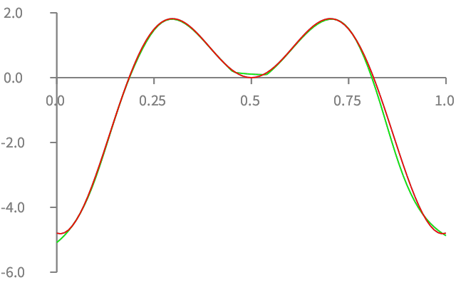

```python
xValues := 0 to: 1.0 by: 0.01.
b := RTGrapher new.
b extent: 300 @ 200.
ds := RTData new.
ds noDot.
ds points: xValues.
ds y: predictor.
ds x: #yourself.
ds connectColor: Color green.
b add: ds.
ds := RTData new.
ds noDot.
ds points: xValues.
ds y: function.
ds x: #yourself.
ds connectColor: Color red.
b add: ds.

self display
        openInJupyter: b
```

```python
self loadScript: IPRoassal js.
```

```python
self display
        interactionOn;
        openInJupyter: graph asRoassalView
```